# CHAPTER A21

# リブおよびフレームに作用する荷重と応力

## A21.1 はじめに

空力的な理由から、翼の翼弦方向の輪郭は目立った歪みが生じることなく維持されなければならない。翼外板がかなり厚くない限り、翼の曲げ効率を高めるために、外板にスパン方向のストリンガー（縦通材）を取り付ける必要がある。したがって、外板とストリンガーからなる翼表面を所定の輪郭形状に保持し、かつストリンガーの長さを制限して効率的な柱圧縮強度を得るためには、内部支持または突っ張り部材が必要となる。これらの構造部材は**翼リブ（wing ribs）**と呼ばれる。  
リブにはもう一つの重要な目的、すなわち荷重の伝達または分配ユニットとしての役割もある。翼に加わるすべての荷重は翼の支持点で反力を受けるため、これらの作用荷重は外板、ストリンガー、桁（スパー）などで構成される翼のセル構造に伝達され、その後、翼の支持点に反力として伝達されなければならない。作用荷重は、この荷重伝達要件を満たすために比較的軽量な内部リブを必要とする、分布した表面空気荷重のみである場合もあれば、着陸装置の反力、動力装置（エンジン）の反力、胴体からの反力などの大きな集中荷重を吸収・伝達しなければならない、かなり頑丈で重量のあるリブである場合もある。これら2つの極端な荷重の大きさの間には、補助翼（エルロン）、フラップ、前縁の高揚力装置などの支持点での反力や、燃料、軍用兵器、その他の装備品などの多数の内部自重荷重がある。このように、リブは、主に形状保持の役割を果たす極めて軽量な構造から、数千ポンドに及ぶ荷重を受け止め伝達しなければならない重構造まで、多岐にわたる。

飛行機の制御面（垂直尾翼、水平尾翼など）は小さな翼にほかならないため、これらの構造にも同様に内部リブが必要とされる。

胴体の外殻を形成する外板・ストリンガー構造も同様に、胴体の断面積を輪郭形状に保持し、ストリンガーの柱長さを制限し、内部および外部から加えられる荷重の伝達媒体として機能する内部成形ユニットを必要とする。通常、胴体には商業輸送機における乗客などのペイロードを収容するための明確な内部空間が必要であるため、一般に**フレーム（frames）**と呼ばれるこれらの内部胴体ユニットは、オープンタイプまたはリングタイプである。胴体フレームは、非常に軽量な成形タイプから、着陸装置の反力、翼の反力、尾翼の反力、動力装置の反力などからの大きな集中荷重を胴体外殻に伝達しなければならない頑丈な重量タイプまで、サイズと強度の点で様々である。胴体内部のすべてのペイロードと固定装備の自重は、胴体床システムなどの他の構造によってフレームに支持され、その後、胴体外殻構造に伝達されなければならない。自重には設計加速度係数を乗じなければならないため、これらの内部荷重は非常に大きな値となる。

リブやフレームのもう一つの重要な目的または作用は、不連続部におけるせん断力を再分配することである。実際の翼や胴体には多くのカットアウト（切り欠き）や開口部が存在するため、基本的な構造配置において不連続性が生じるからである。

## A21.2 翼リブ構造の形式

図 A21.1〜6は、翼構造の一般的なタイプを示している。図 A21.1は前縁用の板金チャンネルを示している。

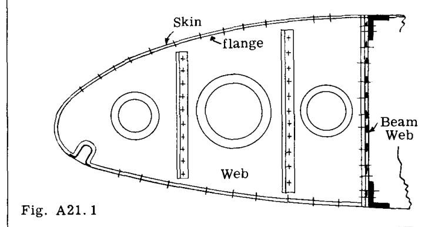

Fig. A21.1

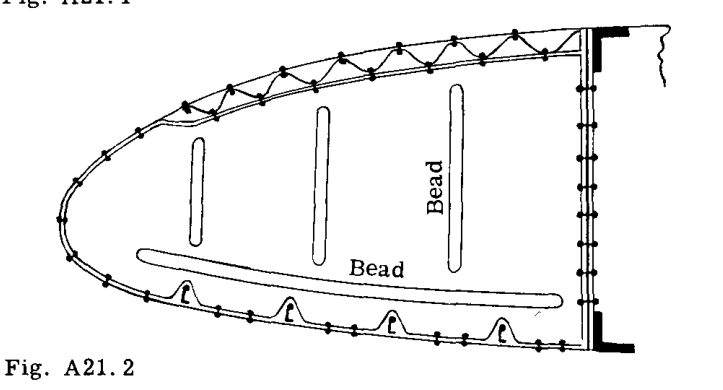

Fig. A21.2

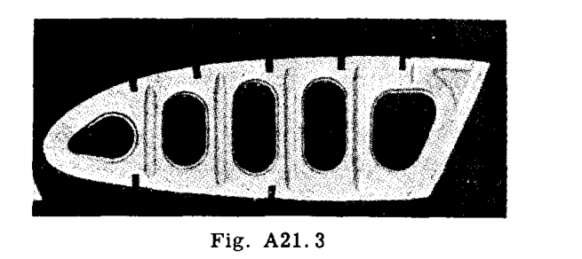

Fig. A21.3

ストリンガー、単一桁、単一セル構成の翼構造。リブは境界に沿って外板にリベット留め、スポット溶接、または接着されている。図 A21.2は同じ前縁セルを示しているが、上部外板にスパン方向のコルゲーション（波板）があり、下部外板にストリンガーが配置されている。上部では、リブのフランジはコルゲーションの下に位置しているが、下部のストリンガーはリブの切り欠きを通過している。図 A21.3は、大型プレスとゴム型（ラバープレス）を使用して迅速に製造できる一般的な板金製リブを示している。図 A21.4および5は、翼断面の中間部分に使用されるリブのタイプを示している。リブのフランジはストリンガーの下側に位置するか、またはストリンガーが通過できるように切り欠き（ノッチ）が設けられている。リブの面内でかなりのねじり力を受けるリブには、外板に対する何らかのせん断連結材（シアータイ）が必要である。ストリンガーの下側に位置するリブの場合、このせん断連結材は、図 A21.5に示すように、数個の板金アングルクリップによって作成できる。図 A21.7は、ビーチクラフト「ボナンザ」商業用航空機の翼構造のパース図を示している。航空機の設計においては、様々なタイプや形状のリブおよびフォーマー（成形材）が必要とされることに留意すべきである。写真 A21.1〜3は、大小様々な航空機における典型的なリブ構造を示している。リブは翼の構造重量の少なからぬ割合を占めるため、安全性が許す限り軽量に作り、かつ製造および組立コストの面でも効率的であることが重要である。リブの開発と設計には、理論的な解析と設計を検証し、支援するために、かなりの静的試験が必要とされる。

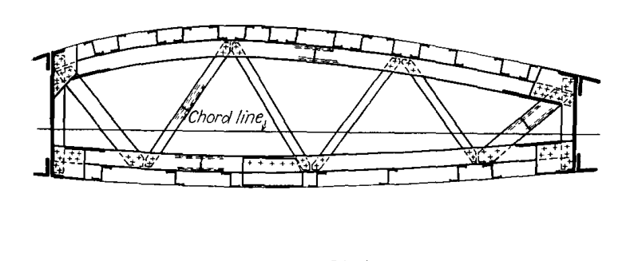

Fig. A21.4

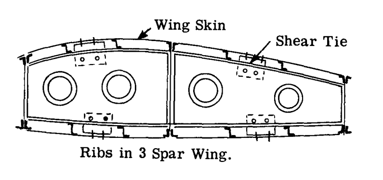

Fig. A21.5

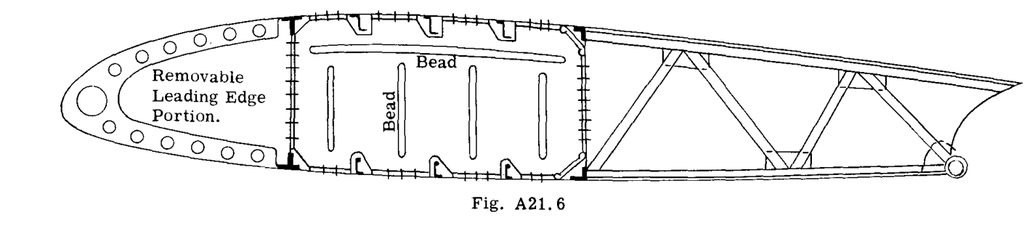

Fig. A21.6

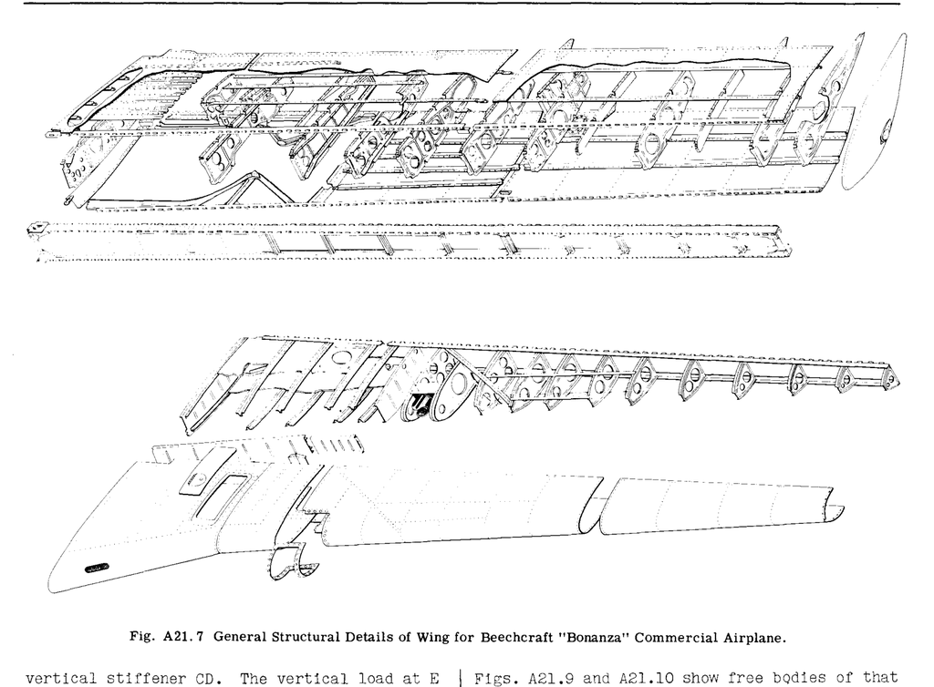

Fig. A21.7 General Structural Details of Wing for Beechcraft “Bonanza” Commercial Airplane.

## A21.3 薄板パネルへの集中荷重の分配

A21.1節において、リブは外部荷重を翼のセル構造梁に伝達するために使用されると述べた。集中外部荷重は、リブが荷重を翼梁構造に伝達する前に、まずリブへ分配されなければならない。言い換えれば、薄い板の端部に集中荷重を直接作用させると、局所的な応力によって板が座屈（バックリング）または圧壊（クリップリング）してしまう。このため、通常はウェブ補強材（ウェボスチフナ）またはウェブフランジと呼ばれる構造部材がウェブに固定され、集中荷重がまず補強材に入り、その補強材が荷重をウェブに伝達する。荷重を補強材に導入するには、通常、エンドフィッティング（端部金具）が必要となる。一般に、翼表面の分布空気荷重は、局所座屈を起こすことなく、リブウェブの端部に対して直角に作用するフランジの直接支持によってリブウェブに分配できる程度の大きさであるため、通常、空気圧を翼リブに伝達するために補強材は必要とされない。

### 例題：薄板パネルへの集中荷重の伝達に関する説明

図 A21.8は、2つのフランジと1つのウェブで構成される片持ち梁を示している。 $1000 \text{ lb}$ の集中荷重が図に示す方向で点(A)に作用している。別の $1000 \text{ lb}$ の集中荷重が図に示すように点(E)に作用している。

点(A)における $1000 \text{ lb}$ の荷重を分配するために、水平補強材(AB)と垂直補強材(CAD)が図に示すように追加されている。点(A)には、両方の補強材に取り付けられるフィッティングが必要となる。 $1000 \text{ lb}$ の荷重の水平成分である $800 \text{ lb}$ は補強材(AB)によって受け持ち、垂直成分である $600 \text{ lb}$ は垂直補強材CDによって受け持たれる。点Eにおける垂直荷重は、点Eのフィッティングを介して補強材EFに伝達される。問題は、ウェブパネルにおけるせん断流、補強材荷重、および梁フランジ荷重を求めることである。

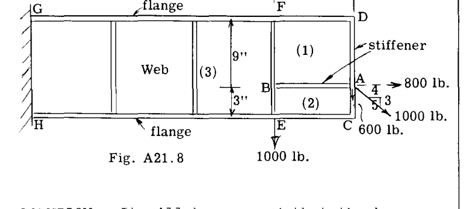

Fig. A21.8

**解法：**  
梁のフランジが梁の曲げモーメントに対する抵抗のすべてを受け持つと仮定する。したがって、ウェブパネル上のせん断流は一定となる。

ウェブパネル(1)および(2)におけるせん断流は、 $1000 \text{ lb}$ の荷重の各成分が別々に作用するものとして計算し、それらの結果を合計して最終的なせん断流を得る。

図 A21.9および図 A21.10は、ウェブパネル(1)および(2)、補強材CADおよびAB、そして(A)における外部荷重を含む部分の自由体を示している。図 A21.9において、上端および下端のせん断流 $q_1$ および $q_2$ は、それぞれ図示された向きであると仮定されている。点Eのまわりのモーメントをとると、

$$\Sigma M_E = 800 \times 3 - 12 \times 10 q_1 = 0 \quad \text{これより} \quad q_1 = 20 \text{ lb./in.}$$

$$\Sigma F_x = 800 - 20 \times 10 - 10 q_2 = 0 \quad \text{これより} \quad q_2 = 60 \text{ lb./in.}$$

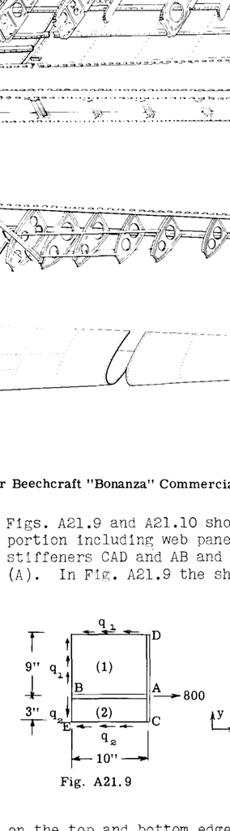

Fig. A21.9

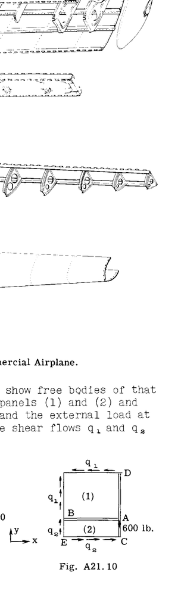

Fig. A21.10

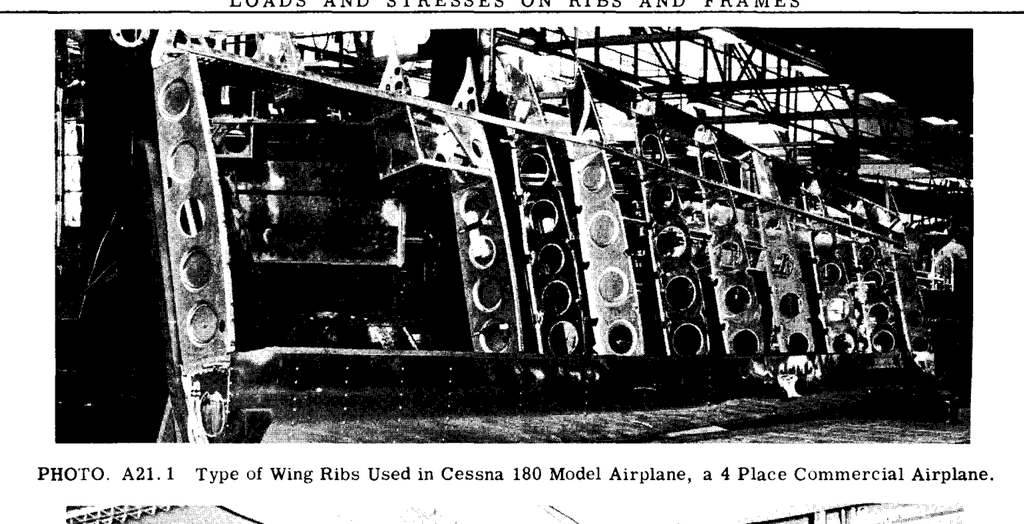

PHOTO. A21.1 Type of Wing Ribs Used in Cessna 180 Model Airplane, a 4 Place Commercial Airplane.

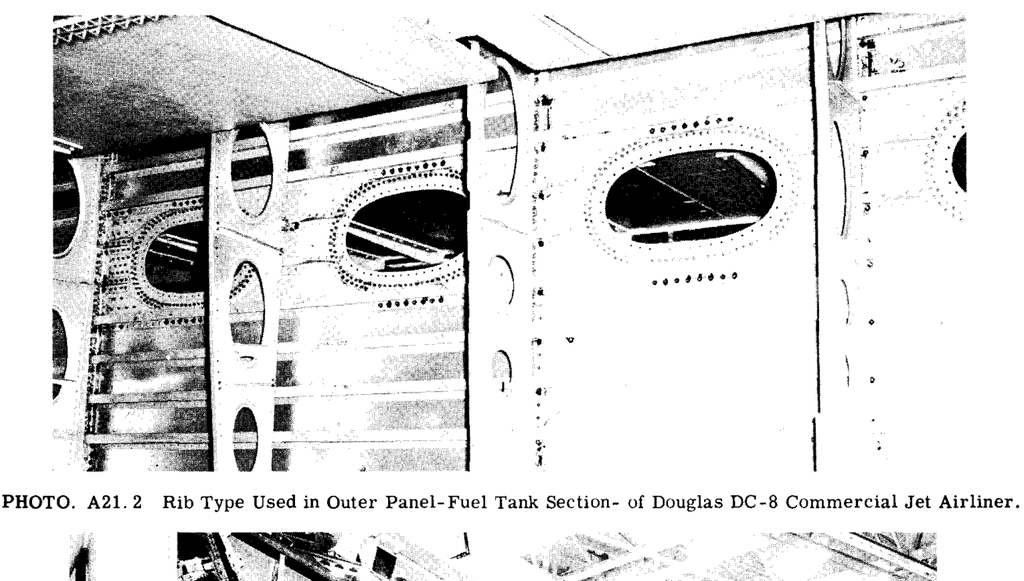

PHOTO. A21.2 Rib Type Used in Outer Panel-Fuel Tank Section- of Douglas DC-8 Commercial Jet Airliner.

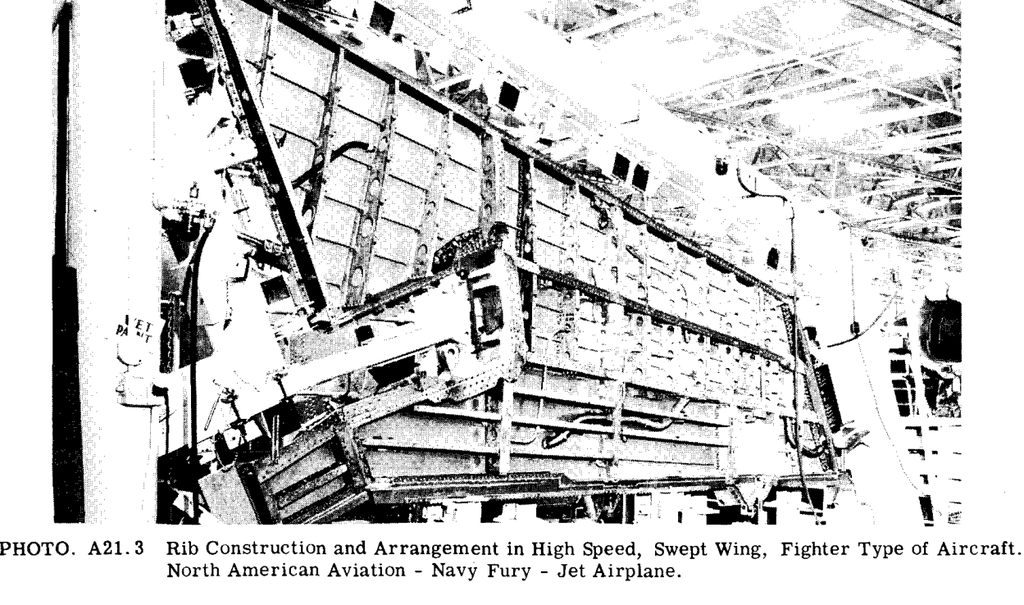

PHOTO. A21.3 Rib Construction and Arrangement in High Speed, Swept Wing, Fighter Type of Aircraft. North American Aviation - Navy Fury - Jet Airplane.

図 A21.10を参照して、

$$\Sigma M_E = 600 \times 10 - 12 \times 10 q_1 = 0 \quad \text{これより} \quad q_1 = 50 \text{ lb./in.}$$

$$\Sigma F_x = -50 \times 10 + 10 q_2 = 0 \quad \text{これより} \quad q_2 = 50 \text{ lb./in.}$$

2つの荷重に対する2つのせん断流を組み合わせると、

$$q_1 = 20 + 50 = 70 \text{ lb./in.}$$

$$q_2 = 60 - 50 = 10 \text{ lb./in.}$$

図 A21.11は、その結果を示している。図 A21.12は補強材ABを自由体として示しており、図 A21.13は補強材ABの軸力図を示している。これは、一端から開始してせん断流を加算していくことで、図 A21.11から直接得られる。

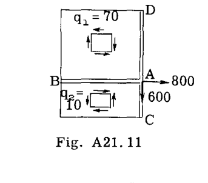

Fig. A21.11

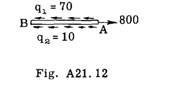

Fig. A21.12

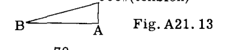

Fig. A21.13

図 A21.14は垂直補強材CADの自由体を示し、図 A21.15はその補強材の軸力図を示している。

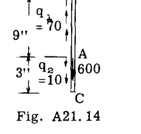

Fig. A21.14

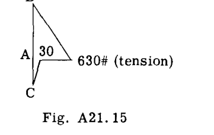

Fig. A21.15

せん断流 $q_1$ と $q_2$ は、もちろん(A)に同時に作用する力の両方の成分を使用して決定することもできる。例えば、図 A21.15aの自由体を考えてみる。

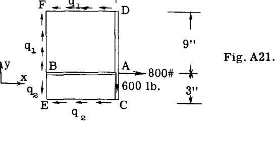

Fig. A21.15a

$$\Sigma F_x = 800 - 10 q_1 - 10 q_2 = 0 \quad \text{--- (1)}$$

$$\Sigma F_y = -600 + 9 q_1 - 3 q_2 = 0 \quad \text{--- (2)}$$

式(1)と(2)を解くと、

$$q_1 = 70 \text{ lb./in.}, \quad q_2 = 10 \text{ lb./in.}$$

となり、最初の解と一致する。

ウェブパネル(3)におけるせん断流 $q_3$ は、補強材EBFを自由体として考慮することによって得られる。図 A21.16を参照。

$$\Sigma F_y = 12 q_3 + 10 \times 3 - 9 \times 70 - 1000 = 0$$

$$\text{これより} \quad q_3 = 133.33 \text{ lb./in.}$$

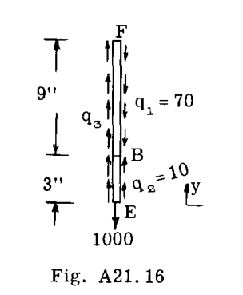

Fig. A21.16

せん断流 $q_3$ は、パネル(3)を通る断面の右側にある梁全体を考慮することによっても求めることができる。この自由体に対して、

$$\Sigma F_y = -600 - 1000 + 12 q_3 = 0$$

$$\text{これより} \quad q_3 = 133.33 \text{ lb./in.}$$

図 A21.17は、図 A21.16から、一端から開始して任意の断面までの力を加算することによって決定された、補強材EFの軸力図を示している。

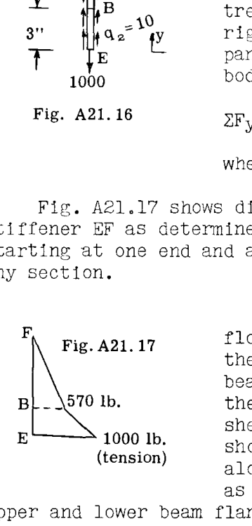

Fig. A21.17

ウェブのせん断流が決定された後、梁フランジの軸力は、せん断流の代数和として得られる。図 A21.18は、以前に求められた各梁フランジに沿ったせん断流を示している。上部および下部の梁フランジ荷重は、各フランジに隣接する図によって示されている。

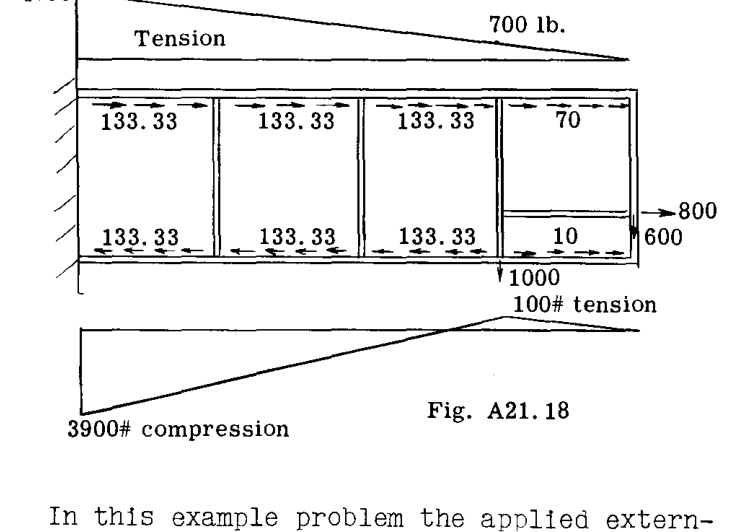

Fig. A21.18

この例題では、点(A)における作用外部荷重は梁ウェブの面内で作用していたため、その2つの成分を処理するには2つの補強材で十分であった。多くの場合、3つの直交する成分を持つ荷重が作用する。この場合、図 A21.19に示すように、作用する力の作用線が2つのウェブの交線上で作用するように構造を配置する必要がある。図 A21.19では、荷重 $P$ が点(O)に作用し、その成分 $P_z, P_y$ および $P_x$ は、(O)で交差する3つの補強材 $S_1, S_2$ および $S_3$ を使用してウェブパネルに分配されている。

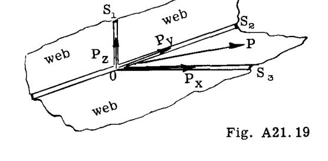

Fig. A21.19

ウェブパネルに対して法線方向に荷重を作用させなければならない場合、補強材は、隣接するウェブへの曲げにおいて荷重を伝達するのに十分な強度を持つように設計されなければならない。

本章では、ウェブは境界に沿って純せん断のみに抵抗すると仮定する。ほとんどの実際の薄いウェブ構造では、ウェブはせん断応力による圧縮応力下で座屈し、せん断応力に加えて引張場応力を発生させる。引張場梁の主題については、第II巻で詳しく説明する。一般に、引張場作用による付加応力は、本章で説明する非座屈の場合について求められた応力に重ね合わせることができる。

## 翼リブにおける応力

### A21.4 単一セル2フランジ梁用のリブ

図 A21.20は、2フランジ単一セル前縁タイプの梁におけるリブを示している。後縁部分（図には示されていない）の空気荷重が、図に示すように偶力反力 $P$ とせん断反力 $R$ を生じさせると仮定する。これらの荷重は、セル壁に連続的に固定されているリブによってセル壁に分配される。与えられた荷重 $P$ および $R$ のもとでリブを平衡状態に保つために必要な、リブ外周上の1インチあたりのせん断流を $q$ とする。

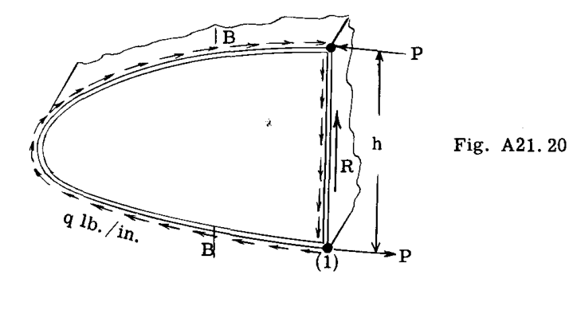

Fig. A21.20

リブの面内にあるすべての力について、点(1)などのいくつかの点まわりのモーメントをとる：

$$\Sigma M_1 = -Ph + 2Aq = 0$$

したがって、

$$q = \frac{Ph}{2A} \quad (A = \text{セルの密閉面積})$$

$q$ が既知となれば、リブに沿った様々な断面におけるせん断力と曲げモーメントを決定することができる。例えば、図 A21.20の断面 B-B を考えてみる。図 A21.21は、この断面より前方部分の自由体を示している。

断面 B-B における曲げモーメントは次式に等しい：

$$M_B = 2qA_1 \quad (A_1 \text{はハッチングされた部分の面積})$$

この断面におけるフランジ荷重の水平成分を $F_x$ とする。

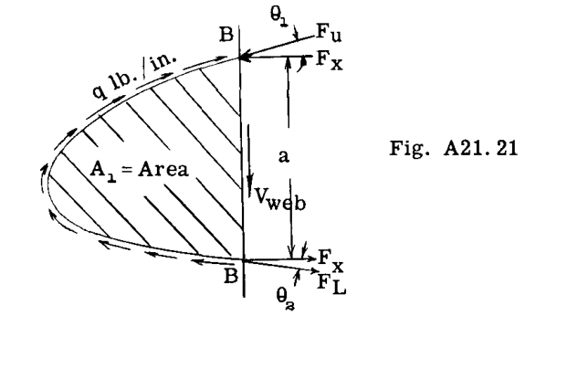

Fig. A21.21

$$F_x = \frac{M_B}{a} = \frac{2qA_1}{a}$$

実際の流線形の上部フランジ荷重は $F_u = F_x / \cos \theta_1$ であり、下部フランジ荷重は $F_L = F_x / \cos \theta_2$ に等しい。

断面 B-B におけるリブウェブの垂直せん断力は、せん断流 $q$ の垂直成分からフランジ荷重の垂直成分を引いたものに等しい。したがって、

$$V_{\text{web}} = q a - F_x \tan \theta_1 - F_x \tan \theta_2$$

$$= q a - \frac{2 q A_1}{a} (\tan \theta_1 + \tan \theta_2)$$

### 例題

図 A21.22に示すような翼の前縁部分のリブを解析する。図示のような分布外部荷重を仮定する。

**解法：**  
梁より後方の全空気荷重 $= 8 \times 40 / 2 = 160 \text{ lb}$ 。梁からその重心位置までの距離は $40 / 3 = 13.33 \text{ in.}$ である。したがって、後縁部分の荷重による梁フランジ点での反力は次のように等しくなる：

$$P = 160 \times 13.33 / 10 = 213.2 \text{ lb} \quad (\text{図 A21.23を参照})$$

せん断反力 $V_r = 160 \text{ lb}$

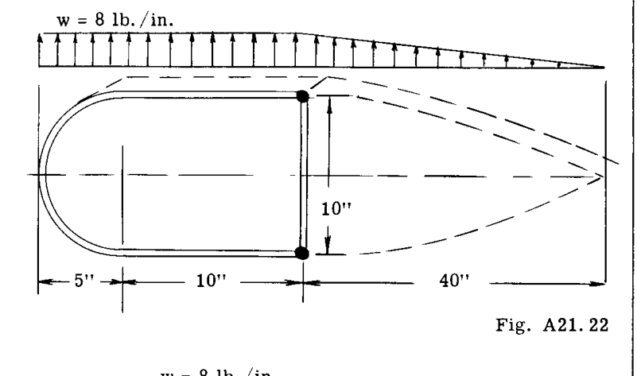

Fig. A21.22

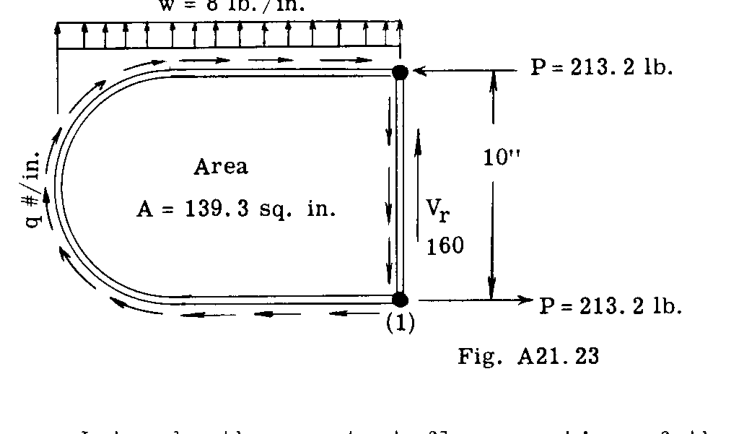

Fig. A21.23

作用する空気荷重のもとでリブを平衡状態に保つために必要な、リブ外周におけるセル外板の一定のせん断流反力を $q$ とする。

下部フランジ(1)などのいくつかの点まわりのモーメントをとる。

$$\Sigma M = -213.2 \times 10 + 8 \times 15 \times 7.5 + 2 \times 139.3 q = 0$$

これより、

$$q = 1232 / 278.6 = 4.42 \text{ lb./in.}$$

リブに作用する力が既知となったので、必要に応じて様々な断面におけるせん断力と曲げモーメントを計算することができる。例えば、前縁から $2.5 \text{ in.}$ の断面 B-B を考える。図 A21.24を参照。

断面 B-B における曲げモーメント $= 8 \times 2.5 \times 1.25 + 4.42 \times 2 \times 15.4 = 161 \text{ in.lb.}$

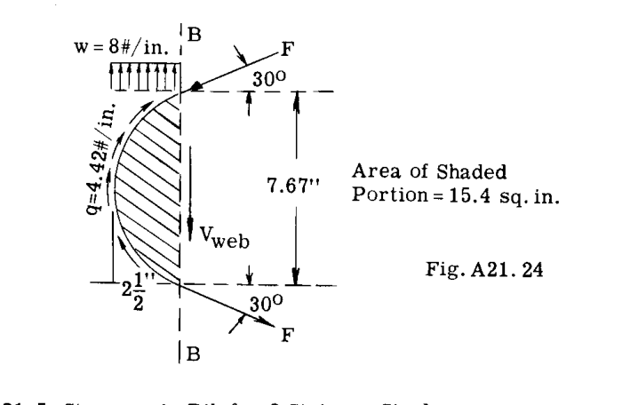

Fig. A21.24